# Tissues

Jeffrey A. Walker

13 September, 2021

# The four primary tissues – introduction

**Tissue** is a level of organization between cells and organs. There are many hundreds if not thousands of cell types. Cells of similar origin and function tend to aggregate together to form one of **four primary tissues**. An organ is composed of all four primary tissues. A tissue includes both **cells** and **extracellular matrix (ECM)**, which is the stuff surrounding cells. Important components of the ECM include protein, electrolytes (especially Na+), some other organic molecules collectively called **ground substance**, and water.

The primary tissues are

1. **epithelial** - composed of cells that line the inner surfaces of tubes (blood vessels, respiratory tubes, kidney tubes, etc) or the outer lining of our body.
2. **connective** - composed of cells that form the skeleton and some odd-ball stuff like blood and adipose tissue
3. **muscle** - composed of cells that contract (generate a force)
4. **nervous** - composed of cells that function in nervous system signaling (kind of a circular definition)
- This classification is pretty good but not perfect. For example, in the *homeostasis explainer*, I mentioned myoepithelial cells, which are epithelial cells but they contract like a muscle cells, and this is why many people mistakenly refer to them as smooth muscle cells. Another example is the cardiac conducting fibers of the heart which are cardiac muscle cells but they don’t contract but they do send electrical signals down their length so they function effectively like neurons, which are nervous tissue cells.

’The word “tissue” has several, other usages

1. cells and ECM occupying the same small bit of space such as “tissue samples”, or “tissue damage”, or “tumor tissue”
2. general functional similarity – cells (and ECM) with similar function such as “skeletal” tissue, “brain tissue”, “adipose tissue”, “cartilage tissue”

Examples of the above can be explored with a google scholar search of [Nature](https://scholar.google.com/scholar?as_q=tissue&as_epq=&as_oq=&as_eq=&as_occt=any&as_sauthors=&as_publication=nature&as_ylo=2016&as_yhi=&hl=en&as_sdt=0%2C20) or [NEJM](https://scholar.google.com/scholar?as_q=tissue&as_epq=&as_oq=&as_eq=&as_occt=any&as_sauthors=&as_publication=new+england+journal+of+medicine&as_ylo=2016&as_yhi=&hl=en&as_sdt=0%2C20)

- Cell types are unique to a tissue.
- organs are composed of all four primary tissues. We tend to think of the organs as the heart, the liver, the brain, the kidney. But a bone is an organ. A muscle is an organ. A blood vessel is an organ (or at least has the structure of an organ). A nerve is an organ (or at least has the structure of an organ). Let’s take a blood vessel. A blood vessel has a wall composed of layers of smooth muscle (muscle tissue), dense connective tissue (connective tissue), and endothelium (epithelium). Nerves run throughout the wall of a blood vessel. A nerve is composed of neurons (nervous tissue) and connective tissue coverings. Small blood vessels run in the wall of nerves and larger blood vessels. We will talk about muscle as a tissue but recognize a muscle, like the biceps muscle is an organ. It is composed of all four primary tissues. The muscle contains blood vessels and nerves. Connective tissue is found in both of these but also the individual muscle cells are wrapped in connective tissue, and bundles of cells are wrapped in connective tissue. We will talk about tendons as “connective tissue” but recognize that a tendon, like the achilles tendon, is an organ (or has organ structure). It is composed of all four primary tissues (I sound like a broken record!)
- this can be confusing. If a physiologist says “bone tissue” they are referring to the mineralized matrix and bone cells (osteocytes)– this is all connective tissue. But “a bone” contains all four primary tissues within its boundaries – it is an organ. The English language is very rich but we don’t have good vocabulary to distinguish “muscle” as a kind of primary tissue and “muscle” as an organ.

## Epithelial tissue

Epithelial tissue forms an **epithelium**. I talk about epithelia (the plural of epithelium) a lot. Epithelia form the lining of all the tubes of our body including 1) the tubes related to our cardiovascular system (blood and lymph vessels and heart), 2) the tubes related to digestion (including our mouth cavity), 3) the tubes in organs that work with digestion including the pancreas and liver, 4) the tubes related to the breathing (respiratory tubes and nasal cavity), 5) the tubes related to kidney function, 6) the tubes related to the urogenital (reproductive) tract, and 7) and the outside layers of our skin. Most of these epithelial are connected…a really small ant could crawl into your mouth all the way into the tiny tubes (ducts) in the pancrea…or the liver…or the kidney…or your lung. Don’t worry, they don’t do this (and the smallest tubes are too small to let an ant through). The point is, most epithelia are connected. One exception is the heart, blood vessels, lymph vessels – the epithelial of these are all connected to each other but not to other epithelia and they have a special name that is very important in physiology: **endothelium** (endo = “internal”, notice that the epithelial in your liver and pancreas and kidney is connected to your outside – the skin). An epithelium-like tissue is the lining of the tubes inside the brain and spinal cord (ventricles, central canal), which is called the ependyma. These are actually nervous tissue cells but many people call this an epithelium. Its not, at least if we define an epithelium as something composed of epithelial tissue.

### A typical tube

All the tubes in our body (including our body wall) have the same basic structure. An inner epithelium that lines the surface, a connective tissue layer deep to the epithelium, and then a layer of smooth muscle (or in the body wall, this is skeletal muscle, and in the heart it is cardiac muscle). There may be alternating layers of connective tissue and muscle. The cavity inside the tube is the **lumen** – I draw this a lot so know this term. Most epithelia, and all epithelia that I talk about, are **simple** – just a single layer of cells.

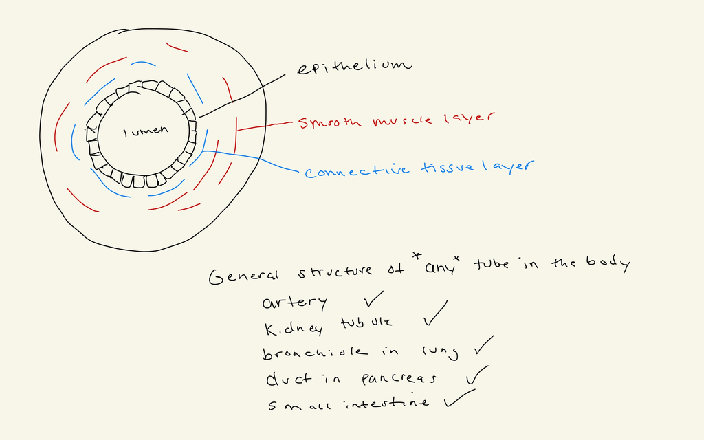

Recognize that the fluid on the lumen side of an epithelium is whatever is contained in the tube – air, or blood, or digesting food, or urine, etc. On the deep (wall side), the fluid is interstitial fluid (IF). The “IF” in my pictures below is interstitial fluid and not the word “if”! Epithelial cells are **polarized** meaning that the organelles align along a distinct lumen <–> interstitial fluid (IF) axis and/or plasma membrane proteins are expressed either on the lumen side or the IF side. The lumen side is called the **apical border** and the plasma membrane on the lumen side of an epithelial cell is the **apical membrane**. The IF side is called the **basolateral border** and the plasma membrane on the IF side of an epithelial cell is the **basolateral membrane**. These are important terms that will be used throughout the course.

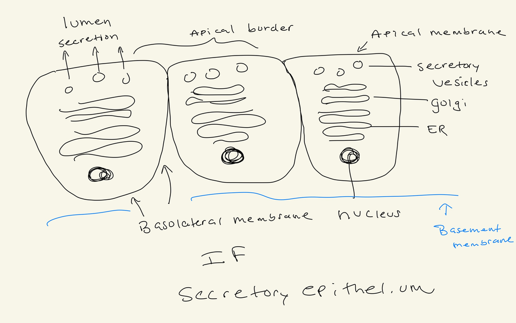

The image below is an epithelium of the proximal convoluted tubule (PCT) of the kidney showing polarity of the membrane proteins. SGLT1 is a Na+ dependent glucose transporter and is expressed on the apical membrane. GLUT2 is a glucose transporter expressed on the basolateral membrane. Also on the basolateral membrane is the Na+/k+ pump.

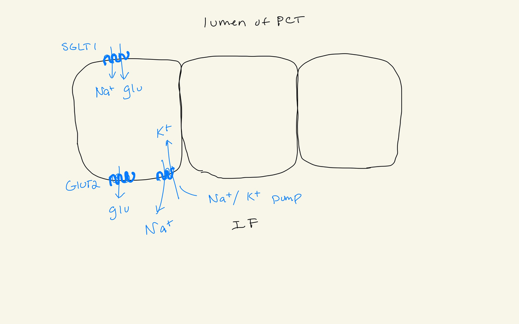

An important epithelium that will occur again and again is composed of a single layer of squamous (=“scale”) epithelial cells. These epithelia are in extremely thin walled tubes – there is no connective tissue or smooth muscle in the wall as the epithelium makes up the entire wall. These epithelial occur in the alveoli (the balloon like ends of the respiratory tubes) and capillaries (the smallest blood vessels, where all exchange of blood content and IF occurs). The thinness optimizes diffusion time across the wall.

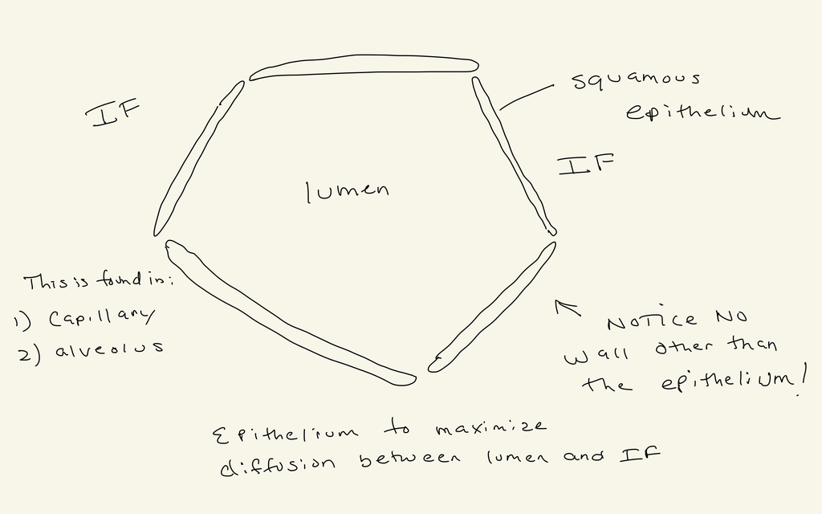

### Some accessory appendages on epithelia.

Cilia are **motile** processes on the apical surface of many epithelia and are used to move stuff in the lumen down the tube. An example is the ciliated epithelium lining the respiratory tubes that move mucus up the bronchi, out of the lung, up the primary bronchus and trachea, to the junction with the esophagus where the mucus is swallowed. This occurs all-day, everyday. Motor proteins occur at the base of each cilium and are used to power the motion. The cilia in our cells are the same as in ciliated eukaryotes like a paramecium. But since a paramecium cell is not locked into place, the cilia make the cell move. We have cells that move through tissues but not by cilia!

microvilli are finger-shaped processes on the apical surface of the intestinal epithelium and is used to increase the surface area of the apical border. This surface is used to digest molecules in our food and absorb digested molecule from the lumen into our blood. The more surface area, the better this works.

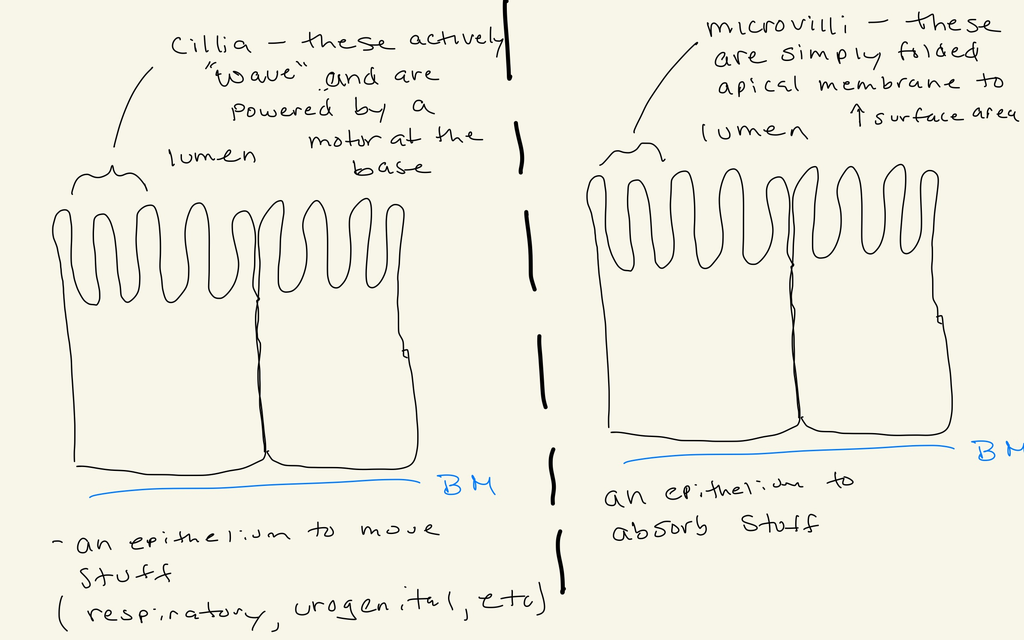

What do I need to know on this page? What message (concept) is the image trying to communicate? For something like the image of the kidney tubule, the concept is the idea that some proteins are expressed only on the apical side while others only on the basolateral side. That is, there is a polarity to protein expression.